# Multiple Linear Regression on Customer Data

Insofe Lab Session

July 02 , 2017

```r
# Go through the data and understand the attributes to get the info of the variables.
```

Write a code to clear the environment if needed

```r
rm(list = ls(all=T))
```

Write a code to set the working directory.

```r
setwd("C:/Users/saite/Desktop/Customer data assignment/MLR assignment")
getwd()
```

```
## [1] "C:/Users/saite/Desktop/Customer data assignment/MLR assignment"
```

Think and load the libraries as and when required in this place only as best practice

```r
#for error evaluation matrix
#Impute the missing values using the "centralImputation()" function from the DMwR package
library(DMwR)
#Standardizing the data
#decostand Using Z score method
library(vegan)
```

```r
# Correlation Plot
library(corrplot)
# The "preProcess()" function creates a model object required for standardizing unseen data
library(caret)
#stepAIC model
#for "stepAIC()" function
library(MASS)
# Modifying the Model with the VIF
# for "vif()" function
library(car)
```

Write a code to read the csv file as “data” as per required

```r
customer_data= read.csv("20170702_Batch30_CSE7302c_CustomerData_Assignment.csv", sep = ",", header = T)
```

Write a code to know the names of the attributes

```r
names(customer_data)
```

```
##  [1] "CustomerID"                   "City"
##  [3] "NoOfChildren"                 "MinAgeOfChild"
##  [5] "MaxAgeOfChild"                "Tenure"
##  [7] "FrquncyOfPurchase"            "NoOfUnitsPurchased"
##  [9] "FrequencyOFPlay"              "NoOfGamesPlayed"
## [11] "NoOfGamesBought"              "FavoriteChannelOfTransaction"
## [13] "FavoriteGame"                 "TotalRevenueGenerated"
```

Write a code to find the dimensions of the data

```r
dim(customer_data)
```

```
## [1] 3209   14
```

Write a code to see the head and tail of the dataset atleast 10rows

```r
head(customer_data,10)
```

```
##    CustomerID City NoOfChildren MinAgeOfChild MaxAgeOfChild Tenure
## 1        1001    1            2             3             8    210
## 2        1002    1            2             3             6    442
## 3        1003    1            4             3             5    424
## 4        1004    1            1             6             6    261
## 5        1005    1            3             6             9    422
## 6        1006    1            2             3             4    378
## 7        1007    1            3             8            12    369
## 8        1008    1            2             6             8    404
## 9        1009    1            4             6             9    420
## 10       1010    2            3             5             6    333
##    FrquncyOfPurchase NoOfUnitsPurchased FrequencyOFPlay NoOfGamesPlayed
## 1                 11                 11            2344             108
## 2                 20                 20             245              22
## 3                 18                 18            1059             130
```

[output cut: 29 more lines]

```r
tail(customer_data,10)
```

```
##      CustomerID City NoOfChildren MinAgeOfChild MaxAgeOfChild Tenure
## 3200       4200    1            1             6             6    352
## 3201       4201    1            2             7             8    313
## 3202       4202    1            3             2             6    424
## 3203       4203    1            2             5             7    424
## 3204       4204    1            1             4             4    431
## 3205       4205    1            2             4             6    365
## 3206       4206    1            2             2             5    348
## 3207       4207    1            2             5             7    341
## 3208       4208    1            2             6             7    368
## 3209       4209    1            3             2             6    389
##      FrquncyOfPurchase NoOfUnitsPurchased FrequencyOFPlay NoOfGamesPlayed
## 3200                27                 24            2042             194
## 3201                15                 15             952             113
## 3202                20                 12            2038             177
```

[output cut: 29 more lines]

Write a code to see the data types of the attributes

```r
str(customer_data)
```

```
## 'data.frame':    3209 obs. of  14 variables:
##  $ CustomerID                  : int  1001 1002 1003 1004 1005 1006 1007 1008 1009 1010 ...
##  $ City                        : int  1 1 1 1 1 1 1 1 1 2 ...
##  $ NoOfChildren                : int  2 2 4 1 3 2 3 2 4 3 ...
##  $ MinAgeOfChild               : int  3 3 3 6 6 3 8 6 6 5 ...
##  $ MaxAgeOfChild               : int  8 6 5 6 9 4 12 8 9 6 ...
##  $ Tenure                      : int  210 442 424 261 422 378 369 404 420 333 ...
##  $ FrquncyOfPurchase           : int  11 20 18 11 44 16 25 13 20 15 ...
##  $ NoOfUnitsPurchased          : int  11 20 18 9 31 16 15 12 16 15 ...
##  $ FrequencyOFPlay             : int  2344 245 1059 365 1066 228 75 1488 2743 1967 ...
##  $ NoOfGamesPlayed             : int  108 22 130 34 102 12 2 118 163 56 ...
##  $ NoOfGamesBought             : int  10 7 18 11 44 16 25 13 16 15 ...
##  $ FavoriteChannelOfTransaction: Factor w/ 2 levels "Favorite","Uniform": 2 1 1 1 2 1 1 1 2 1 ...
##  $ FavoriteGame                : Factor w/ 3 levels "Favorite","NONE",..: 3 3 3 3 3 1 1 3 3 3 ...
##  $ TotalRevenueGenerated       : num  108 382 135 125 335 ...
```

Write a code to remove the unuseful variables and store the data

```r
customer_data<- customer_data[,-c(1,2)]
colnames(customer_data)
```

```
##  [1] "NoOfChildren"                 "MinAgeOfChild"
##  [3] "MaxAgeOfChild"                "Tenure"
##  [5] "FrquncyOfPurchase"            "NoOfUnitsPurchased"
##  [7] "FrequencyOFPlay"              "NoOfGamesPlayed"
##  [9] "NoOfGamesBought"              "FavoriteChannelOfTransaction"
## [11] "FavoriteGame"                 "TotalRevenueGenerated"
```

Write a code to observe the variables and convert them into the required formats

```r
##data_num[,num_Attr] <- data.frame(apply(data_num[,num_Attr],2,function(x) as.numeric(x)))
```

Check the changes again using str() command

```r
##str(object = data_num)
```

Write a Code to seperate the target

```r
orig_data_without_target = customer_data[,-c(12)]
colnames(orig_data_without_target)
```

```
##  [1] "NoOfChildren"                 "MinAgeOfChild"
##  [3] "MaxAgeOfChild"                "Tenure"
##  [5] "FrquncyOfPurchase"            "NoOfUnitsPurchased"
##  [7] "FrequencyOFPlay"              "NoOfGamesPlayed"
##  [9] "NoOfGamesBought"              "FavoriteChannelOfTransaction"
## [11] "FavoriteGame"
```

Write a code to get the numerical attributes out and store them as data_num

```r
cat_Attr <- c("FavoriteGame","FavoriteChannelOfTransaction")
num_Attr <- setdiff(x = names(orig_data_without_target),y = cat_Attr)

data_num <- orig_data_without_target[num_Attr]
str(data_num)
```

```
## 'data.frame':    3209 obs. of  9 variables:
##  $ NoOfChildren      : int  2 2 4 1 3 2 3 2 4 3 ...
##  $ MinAgeOfChild     : int  3 3 3 6 6 3 8 6 6 5 ...
##  $ MaxAgeOfChild     : int  8 6 5 6 9 4 12 8 9 6 ...
##  $ Tenure            : int  210 442 424 261 422 378 369 404 420 333 ...
##  $ FrquncyOfPurchase : int  11 20 18 11 44 16 25 13 20 15 ...
##  $ NoOfUnitsPurchased: int  11 20 18 9 31 16 15 12 16 15 ...
##  $ FrequencyOFPlay   : int  2344 245 1059 365 1066 228 75 1488 2743 1967 ...
##  $ NoOfGamesPlayed   : int  108 22 130 34 102 12 2 118 163 56 ...
##  $ NoOfGamesBought   : int  10 7 18 11 44 16 25 13 16 15 ...
```

Write a code to observe the variables and convert them into the required formats

```r
data_num[,num_Attr] <- data.frame(apply(data_num[,num_Attr],2,function(x) as.numeric(x)))
```

Check the changes again using str() command

```r
str(object = data_num)
```

```
## 'data.frame':    3209 obs. of  9 variables:
##  $ NoOfChildren      : num  2 2 4 1 3 2 3 2 4 3 ...
##  $ MinAgeOfChild     : num  3 3 3 6 6 3 8 6 6 5 ...
##  $ MaxAgeOfChild     : num  8 6 5 6 9 4 12 8 9 6 ...
##  $ Tenure            : num  210 442 424 261 422 378 369 404 420 333 ...
##  $ FrquncyOfPurchase : num  11 20 18 11 44 16 25 13 20 15 ...
##  $ NoOfUnitsPurchased: num  11 20 18 9 31 16 15 12 16 15 ...
##  $ FrequencyOFPlay   : num  2344 245 1059 365 1066 ...
##  $ NoOfGamesPlayed   : num  108 22 130 34 102 12 2 118 163 56 ...
##  $ NoOfGamesBought   : num  10 7 18 11 44 16 25 13 16 15 ...
```

Write a code for Normalizing the data_num

```r
data_num <- decostand(data_num,"standardize") # Using Z score method
summary(data_num)
```

```
##   NoOfChildren     MinAgeOfChild      MaxAgeOfChild
##  Min.   :-1.0901   Min.   :-1.33562   Min.   :-0.568147
##  1st Qu.:-1.0901   1st Qu.:-0.25867   1st Qu.:-0.226620
##  Median :-0.1240   Median : 0.01057   Median :-0.112778
##  Mean   : 0.0000   Mean   : 0.00000   Mean   : 0.000000
##  3rd Qu.: 0.8421   3rd Qu.: 0.27981   3rd Qu.: 0.001064
##  Max.   : 8.5708   Max.   :29.08824   Max.   :11.954501
##      Tenure        FrquncyOfPurchase NoOfUnitsPurchased FrequencyOFPlay
##  Min.   :-2.7344   Min.   :-1.8088   Min.   :-1.9053    Min.   :-0.8661
##  1st Qu.:-0.5139   1st Qu.:-0.6242   1st Qu.:-0.6522    1st Qu.:-0.6198
##  Median : 0.2262   Median :-0.2689   Median :-0.2345    Median :-0.2978
##  Mean   : 0.0000   Mean   : 0.0000   Mean   : 0.0000    Mean   : 0.0000
##  3rd Qu.: 0.7676   3rd Qu.: 0.3234   3rd Qu.: 0.3225    3rd Qu.: 0.2545
##  Max.   : 1.3752   Max.   :12.1694   Max.   :13.5499    Max.   :14.5037
##  NoOfGamesPlayed   NoOfGamesBought
##  Min.   :-1.0528   Min.   :-1.6824
##  1st Qu.:-0.6367   1st Qu.:-0.5427
##  Median :-0.2657   Median :-0.0868
##  Mean   : 0.0000   Mean   : 0.0000
##  3rd Qu.: 0.2853   3rd Qu.: 0.4831
##  Max.   :12.0577   Max.   :11.4246
```

Write a code to observe the correlation between the attributes

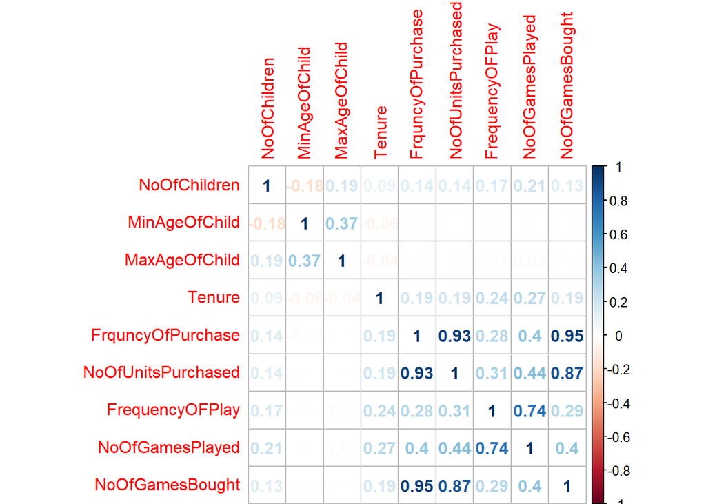

```r
corrplot(cor(data_num), method = "number")
```

Write a code to plot the corrplot of correlation between the attributes

```r
#done already
```

Write a code to seperate the categorical attributes

```r
cat_Attr <- c("FavoriteGame","FavoriteChannelOfTransaction")

data_cat <- orig_data_without_target[cat_Attr]
str(data_cat)
```

```
## 'data.frame':    3209 obs. of  2 variables:
##  $ FavoriteGame                : Factor w/ 3 levels "Favorite","NONE",..: 3 3 3 3 3 1 1 3 3 3 ...
##  $ FavoriteChannelOfTransaction: Factor w/ 2 levels "Favorite","Uniform": 2 1 1 1 2 1 1 1 2 1 ...
```

Write a code to combine the numerical,categorical data along with the target

```r
str(customer_data)
```

```
## 'data.frame':    3209 obs. of  12 variables:
##  $ NoOfChildren                : int  2 2 4 1 3 2 3 2 4 3 ...
##  $ MinAgeOfChild               : int  3 3 3 6 6 3 8 6 6 5 ...
##  $ MaxAgeOfChild               : int  8 6 5 6 9 4 12 8 9 6 ...
##  $ Tenure                      : int  210 442 424 261 422 378 369 404 420 333 ...
##  $ FrquncyOfPurchase           : int  11 20 18 11 44 16 25 13 20 15 ...
##  $ NoOfUnitsPurchased          : int  11 20 18 9 31 16 15 12 16 15 ...
##  $ FrequencyOFPlay             : int  2344 245 1059 365 1066 228 75 1488 2743 1967 ...
##  $ NoOfGamesPlayed             : int  108 22 130 34 102 12 2 118 163 56 ...
##  $ NoOfGamesBought             : int  10 7 18 11 44 16 25 13 16 15 ...
##  $ FavoriteChannelOfTransaction: Factor w/ 2 levels "Favorite","Uniform": 2 1 1 1 2 1 1 1 2 1 ...
##  $ FavoriteGame                : Factor w/ 3 levels "Favorite","NONE",..: 3 3 3 3 3 1 1 3 3 3 ...
##  $ TotalRevenueGenerated       : num  108 382 135 125 335 ...
```

```r
df_final_customer_data = cbind(data_num,data_cat,customer_data[,12, drop=FALSE])

str (df_final_customer_data)
```

```
## 'data.frame':    3209 obs. of  12 variables:
##  $ NoOfChildren                : num  -0.124 -0.124 1.808 -1.09 0.842 ...
##  $ MinAgeOfChild               : num  -0.528 -0.528 -0.528 0.28 0.28 ...
##  $ MaxAgeOfChild               : num  0.00106 -0.22662 -0.34046 -0.22662 0.11491 ...
##  $ Tenure                      : num  -1.519 1.044 0.845 -0.956 0.823 ...
##  $ FrquncyOfPurchase           : num  -0.624 0.442 0.205 -0.624 3.285 ...
##  $ NoOfUnitsPurchased          : num  -0.513 0.74 0.462 -0.791 2.272 ...
##  $ FrequencyOFPlay             : num  0.428 -0.731 -0.281 -0.665 -0.277 ...
##  $ NoOfGamesPlayed             : num  0.1616 -0.8054 0.409 -0.6705 0.0941 ...
##  $ NoOfGamesBought             : num  -0.543 -0.885 0.369 -0.429 3.332 ...
##  $ FavoriteGame                : Factor w/ 3 levels "Favorite","NONE",..: 3 3 3 3 3 1 1 3 3 3 ...
##  $ FavoriteChannelOfTransaction: Factor w/ 2 levels "Favorite","Uniform": 2 1 1 1 2 1 1 1 2 1 ...
##  $ TotalRevenueGenerated       : num  108 382 135 125 335 ...
```

Write a code to set the seed and comment why it is used.

```r
set.seed(29)
#seeding is done, so that each time after random data split we get exactly the same dataset for training and testing.
```

Write a code to get the train rows using sample

```r
train_rows <- sample(x = 1:nrow(df_final_customer_data), size = 0.7*nrow(df_final_customer_data))
```

Write a code to get the train and test

```r
train_data <- df_final_customer_data[train_rows, ]

test_data <- df_final_customer_data[-train_rows, ]
```

Write a code to just plot the grahs between attributes and targets

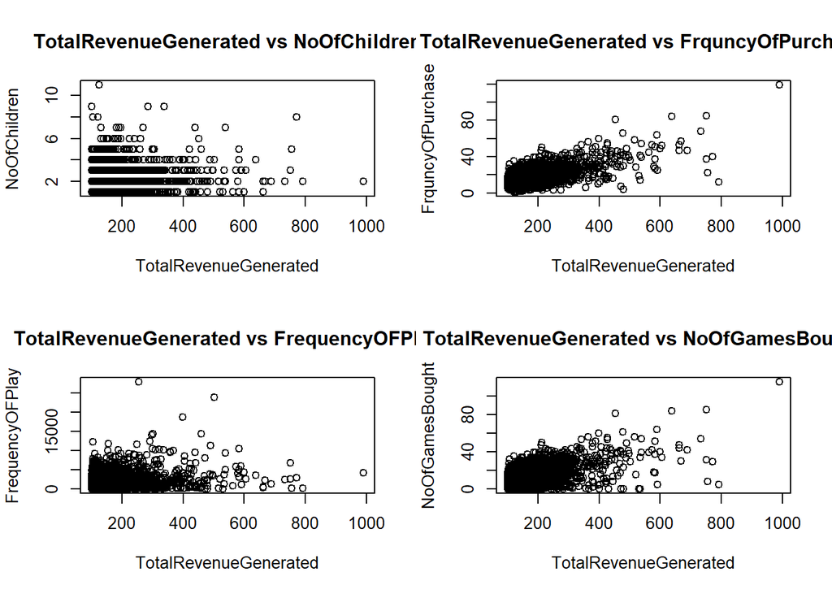

```r
par(mfrow = c(2,2))

plot(customer_data$TotalRevenueGenerated, customer_data$NoOfChildren, xlab = "TotalRevenueGenerated", ylab = "NoOfChildren", main = "TotalRevenueGenerated vs NoOfChildren")

plot(customer_data$TotalRevenueGenerated, customer_data$FrquncyOfPurchase, xlab = "TotalRevenueGenerated", ylab = "FrquncyOfPurchase", main = "TotalRevenueGenerated vs FrquncyOfPurchase")

plot(customer_data$TotalRevenueGenerated, customer_data$FrequencyOFPlay, xlab = "TotalRevenueGenerated", ylab = "FrequencyOFPlay", main = "TotalRevenueGenerated vs FrequencyOFPlay")

plot(customer_data$TotalRevenueGenerated, customer_data$NoOfGamesBought, xlab = "TotalRevenueGenerated", ylab = "NoOfGamesBought", main = "TotalRevenueGenerated vs NoOfGamesBought")
```

Write a code to form a linear regression model

```r
model_basic <- lm(TotalRevenueGenerated ~. , data = train_data)
```

Write a code to plot the model

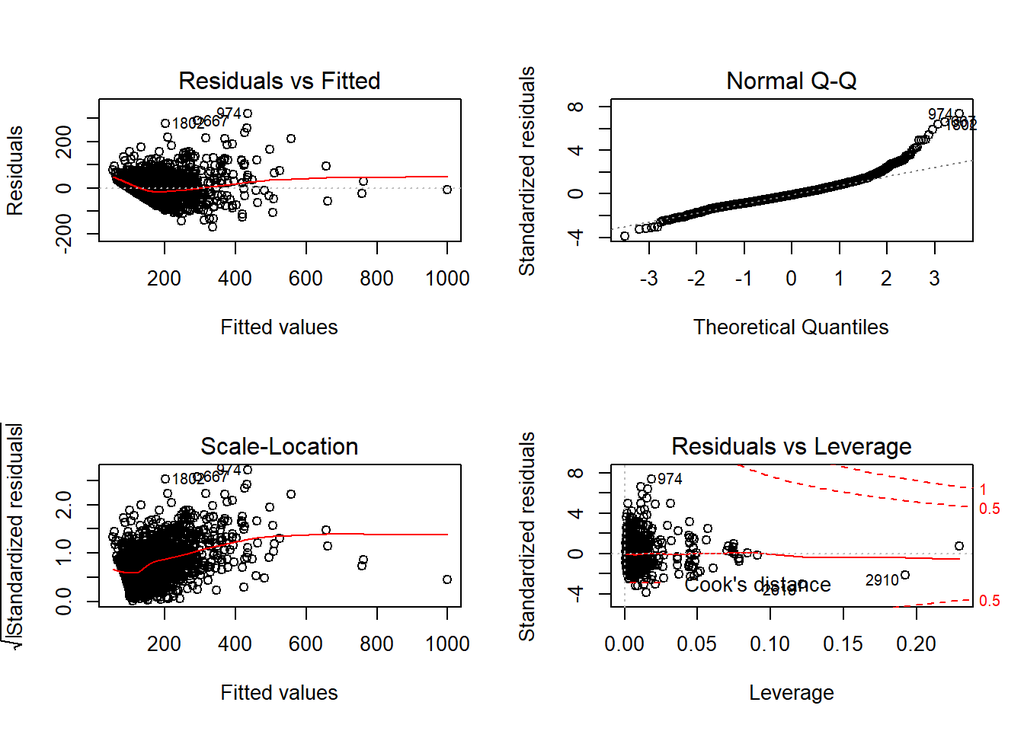

```r
par(mfrow = c(2,2))

plot(model_basic)
```

Write a code to check the summary of the model

```r
summary(model_basic)
```

```
##
## Call:
## lm(formula = TotalRevenueGenerated ~ ., data = train_data)
##
## Residuals:
##     Min      1Q  Median      3Q     Max
## -169.33  -27.47   -3.95   21.85  320.54
##
## Coefficients:
##                                     Estimate Std. Error t value Pr(>|t|)
## (Intercept)                         184.4822     4.6710  39.496  < 2e-16
## NoOfChildren                          3.6228     1.0314   3.513 0.000453
## MinAgeOfChild                        13.6671     2.2576   6.054 1.65e-09
## MaxAgeOfChild                        -1.8085     0.9929  -1.821 0.068677
## Tenure                               -0.6096     0.9758  -0.625 0.532258
## FrquncyOfPurchase                    84.2269     4.2221  19.949  < 2e-16
## NoOfUnitsPurchased                   69.5887     2.6879  25.889  < 2e-16
## FrequencyOFPlay                       4.3932     1.4188   3.096 0.001984
## NoOfGamesPlayed                      -3.8275     1.5221  -2.515 0.011986
## NoOfGamesBought                     -98.3696     3.0554 -32.195  < 2e-16
## FavoriteGameNONE                      3.2075    10.2806   0.312 0.755074
## FavoriteGameUniform                 -12.5140     4.7496  -2.635 0.008479
## FavoriteChannelOfTransactionUniform -15.1745     2.4653  -6.155 8.86e-10
##
## (Intercept)                         ***
## NoOfChildren                        ***
## MinAgeOfChild                       ***
## MaxAgeOfChild                       .
## Tenure
## FrquncyOfPurchase                   ***
## NoOfUnitsPurchased                  ***
## FrequencyOFPlay                     **
## NoOfGamesPlayed                     *
## NoOfGamesBought                     ***
## FavoriteGameNONE
## FavoriteGameUniform                 **
## FavoriteChannelOfTransactionUniform ***
## ---
## Signif. codes:  0 '***' 0.001 '**' 0.01 '*' 0.05 '.' 0.1 ' ' 1
##
## Residual standard error: 43.95 on 2233 degrees of freedom
## Multiple R-squared:  0.7245, Adjusted R-squared:  0.723
## F-statistic: 489.3 on 12 and 2233 DF,  p-value: < 2.2e-16
```

Write a code to predict the value of the target on the linear model

```r
preds_model <- predict(model_basic, test_data[,-c(12)] )
```

Write a code to use stepAIC

```r
model_aic <- stepAIC(model_basic, direction = "both")
```

```
## Start:  AIC=17006.39
## TotalRevenueGenerated ~ NoOfChildren + MinAgeOfChild + MaxAgeOfChild +
##     Tenure + FrquncyOfPurchase + NoOfUnitsPurchased + FrequencyOFPlay +
##     NoOfGamesPlayed + NoOfGamesBought + FavoriteGame + FavoriteChannelOfTransaction
##
##                                Df Sum of Sq     RSS   AIC
## - Tenure                        1       754 4313934 17005
## <none>                                      4313180 17006
## - MaxAgeOfChild                 1      6408 4319588 17008
## - NoOfGamesPlayed               1     12214 4325394 17011
## - FavoriteGame                  2     18030 4331211 17012
## - FrequencyOFPlay               1     18518 4331698 17014
## - NoOfChildren                  1     23833 4337013 17017
## - MinAgeOfChild                 1     70791 4383971 17041
## - FavoriteChannelOfTransaction  1     73180 4386360 17042
## - FrquncyOfPurchase             1    768700 5081881 17373
## - NoOfUnitsPurchased            1   1294627 5607807 17594
## - NoOfGamesBought               1   2002139 6315319 17861
##
## Step:  AIC=17004.78
## TotalRevenueGenerated ~ NoOfChildren + MinAgeOfChild + MaxAgeOfChild +
##     FrquncyOfPurchase + NoOfUnitsPurchased + FrequencyOFPlay +
##     NoOfGamesPlayed + NoOfGamesBought + FavoriteGame + FavoriteChannelOfTransaction
##
##                                Df Sum of Sq     RSS   AIC
## <none>                                      4313934 17005
## - MaxAgeOfChild                 1      6180 4320114 17006
## + Tenure                        1       754 4313180 17006
## - NoOfGamesPlayed               1     12894 4326828 17010
## - FavoriteGame                  2     18105 4332039 17010
## - FrequencyOFPlay               1     18051 4331985 17012
## - NoOfChildren                  1     23891 4337825 17015
## - FavoriteChannelOfTransaction  1     72833 4386767 17040
## - MinAgeOfChild                 1     73621 4387555 17041
## - FrquncyOfPurchase             1    767977 5081911 17371
## - NoOfUnitsPurchased            1   1297272 5611206 17593
## - NoOfGamesBought               1   2002220 6316153 17859
```

```r
summary(model_aic)
```

```
##
## Call:
## lm(formula = TotalRevenueGenerated ~ NoOfChildren + MinAgeOfChild +
##     MaxAgeOfChild + FrquncyOfPurchase + NoOfUnitsPurchased +
##     FrequencyOFPlay + NoOfGamesPlayed + NoOfGamesBought + FavoriteGame +
##     FavoriteChannelOfTransaction, data = train_data)
##
## Residuals:
##     Min      1Q  Median      3Q     Max
## -169.04  -27.33   -4.07   22.12  320.15
##
## Coefficients:
##                                     Estimate Std. Error t value Pr(>|t|)
## (Intercept)                         184.5133     4.6701  39.510  < 2e-16
## NoOfChildren                          3.6272     1.0312   3.517 0.000444
## MinAgeOfChild                        13.8365     2.2409   6.175 7.86e-10
## MaxAgeOfChild                        -1.7731     0.9912  -1.789 0.073754
## FrquncyOfPurchase                    84.1278     4.2185  19.942  < 2e-16
## NoOfUnitsPurchased                   69.6342     2.6866  25.919  < 2e-16
## FrequencyOFPlay                       4.3244     1.4144   3.057 0.002259
## NoOfGamesPlayed                      -3.9157     1.5153  -2.584 0.009827
## NoOfGamesBought                     -98.3715     3.0550 -32.200  < 2e-16
## FavoriteGameNONE                      3.1585    10.2789   0.307 0.758660
## FavoriteGameUniform                 -12.5524     4.7486  -2.643 0.008265
## FavoriteChannelOfTransactionUniform -15.1330     2.4641  -6.141 9.65e-10
##
## (Intercept)                         ***
## NoOfChildren                        ***
## MinAgeOfChild                       ***
## MaxAgeOfChild                       .
## FrquncyOfPurchase                   ***
## NoOfUnitsPurchased                  ***
## FrequencyOFPlay                     **
## NoOfGamesPlayed                     **
## NoOfGamesBought                     ***
## FavoriteGameNONE
## FavoriteGameUniform                 **
## FavoriteChannelOfTransactionUniform ***
## ---
## Signif. codes:  0 '***' 0.001 '**' 0.01 '*' 0.05 '.' 0.1 ' ' 1
##
## Residual standard error: 43.94 on 2234 degrees of freedom
## Multiple R-squared:  0.7244, Adjusted R-squared:  0.7231
## F-statistic: 533.9 on 11 and 2234 DF,  p-value: < 2.2e-16
```

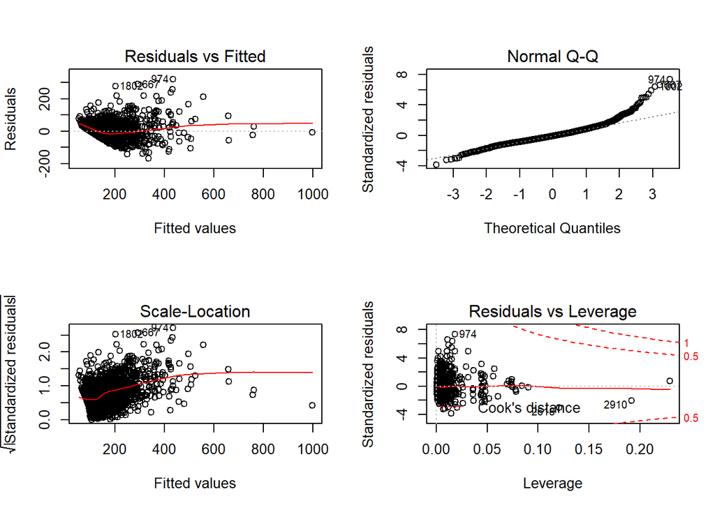

```r
par(mfrow = c(2,2))
plot(model_aic)
```

Write a code to predict it on stepAIC

```r
preds_model_aic <- predict(model_aic, test_data[,-c(12)])
```

Write a code to check the multicollinearity in the lm model

```r
vif(model_basic)
```

```
##                                   GVIF Df GVIF^(1/(2*Df))
## NoOfChildren                  1.269099  1        1.126543
## MinAgeOfChild                 1.203269  1        1.096936
## MaxAgeOfChild                 1.071565  1        1.035164
## Tenure                        1.120442  1        1.058510
## FrquncyOfPurchase            20.969294  1        4.579224
## NoOfUnitsPurchased            8.488265  1        2.913463
## FrequencyOFPlay               2.218613  1        1.489501
## NoOfGamesPlayed               2.533376  1        1.591658
## NoOfGamesBought              10.838043  1        3.292118
## FavoriteGame                  1.072448  2        1.017640
## FavoriteChannelOfTransaction  1.082285  1        1.040329
```

Write a code to check the plots of the models

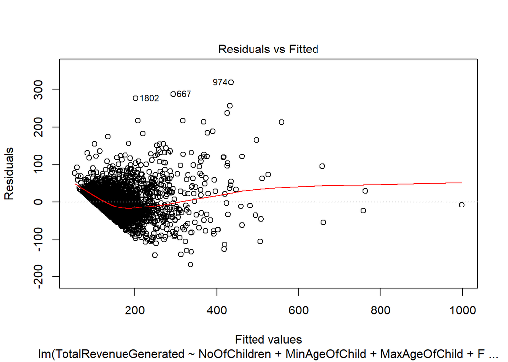

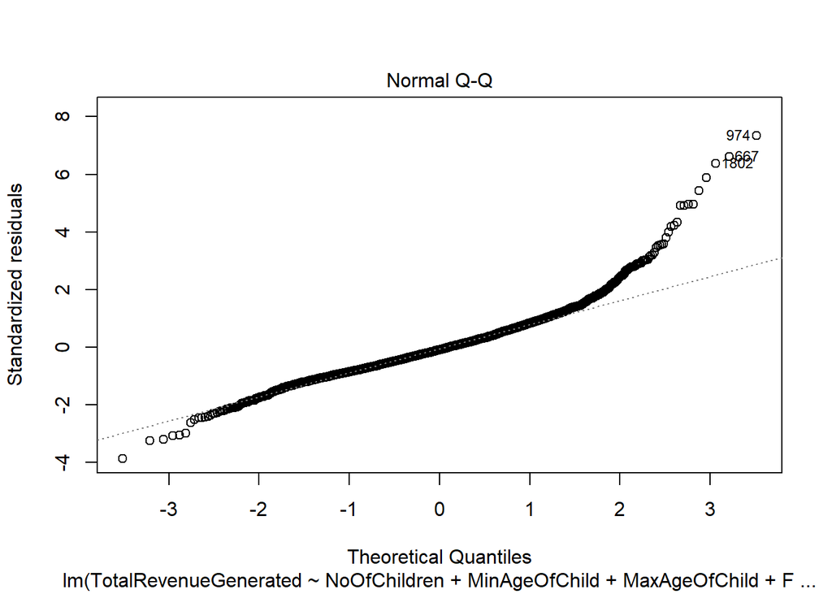

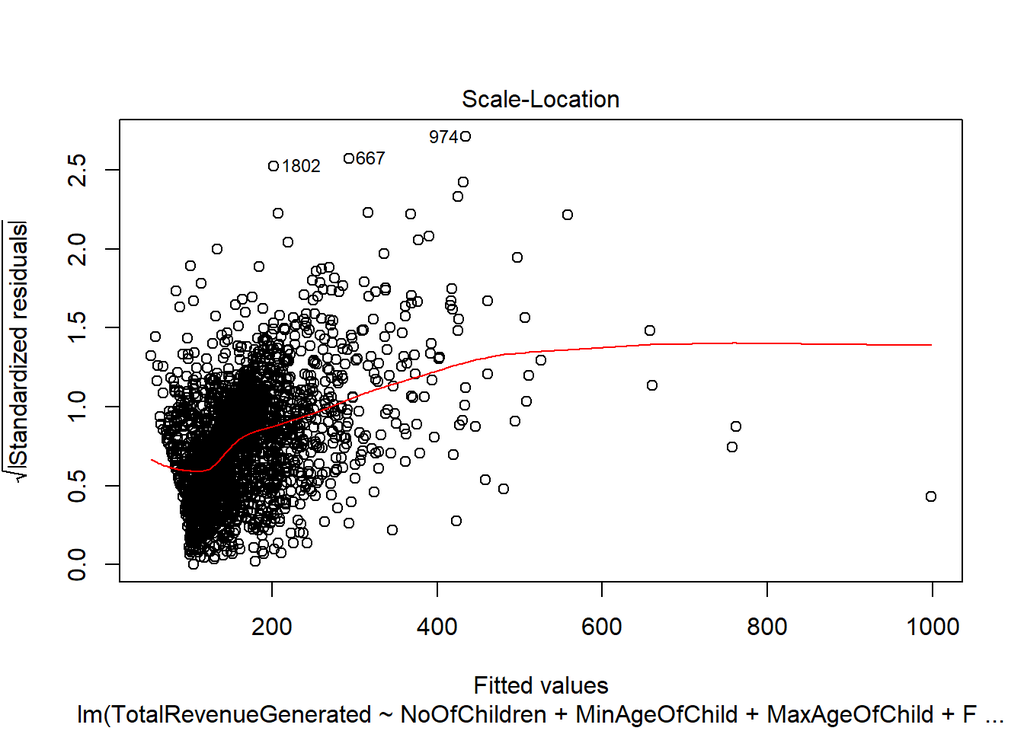

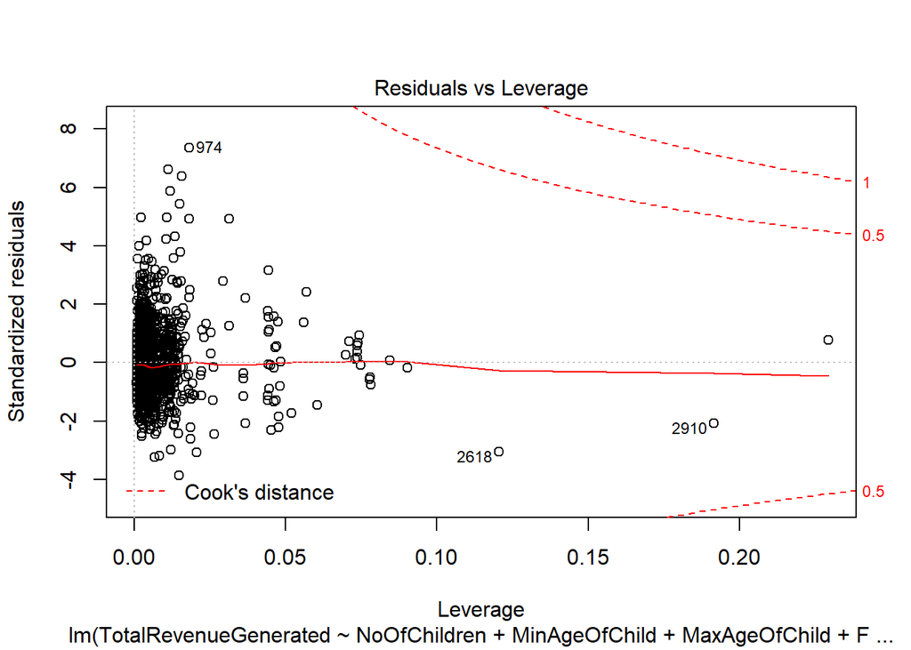

```r
plot(model_aic)
```

Write a code to check the multicollinearity problem

```r
cor(customer_data$FrquncyOfPurchase , customer_data$NoOfGamesBought)
```

```
## [1] 0.9477875
```

```r
model3 <- lm(formula = TotalRevenueGenerated ~ MinAgeOfChild + MaxAgeOfChild + Tenure + FrequencyOFPlay + NoOfGamesPlayed + FavoriteGame + NoOfChildren + NoOfUnitsPurchased + FavoriteChannelOfTransaction, data = train_data)

summary(model3)
```

```
##
## Call:
## lm(formula = TotalRevenueGenerated ~ MinAgeOfChild + MaxAgeOfChild +
##     Tenure + FrequencyOFPlay + NoOfGamesPlayed + FavoriteGame +
##     NoOfChildren + NoOfUnitsPurchased + FavoriteChannelOfTransaction,
##     data = train_data)
##
## Residuals:
##     Min      1Q  Median      3Q     Max
## -140.77  -32.55   -8.59   17.56  460.81
##
## Coefficients:
##                                     Estimate Std. Error t value Pr(>|t|)
## (Intercept)                          195.208      5.700  34.244  < 2e-16
## MinAgeOfChild                         10.470      2.759   3.795 0.000152
## MaxAgeOfChild                         -1.548      1.215  -1.274 0.202671
## Tenure                                -1.172      1.192  -0.983 0.325648
## FrequencyOFPlay                        3.007      1.735   1.733 0.083202
## NoOfGamesPlayed                       -5.532      1.860  -2.974 0.002971
## FavoriteGameNONE                      30.656     12.538   2.445 0.014561
## FavoriteGameUniform                  -24.608      5.794  -4.247 2.26e-05
## NoOfChildren                           3.245      1.262   2.572 0.010163
## NoOfUnitsPurchased                    65.258      1.263  51.683  < 2e-16
## FavoriteChannelOfTransactionUniform  -16.023      2.908  -5.510 3.99e-08
##
## (Intercept)                         ***
## MinAgeOfChild                       ***
## MaxAgeOfChild
## Tenure
## FrequencyOFPlay                     .
## NoOfGamesPlayed                     **
## FavoriteGameNONE                    *
## FavoriteGameUniform                 ***
## NoOfChildren                        *
## NoOfUnitsPurchased                  ***
## FavoriteChannelOfTransactionUniform ***
## ---
## Signif. codes:  0 '***' 0.001 '**' 0.01 '*' 0.05 '.' 0.1 ' ' 1
##
## Residual standard error: 53.77 on 2235 degrees of freedom
## Multiple R-squared:  0.5872, Adjusted R-squared:  0.5853
## F-statistic: 317.9 on 10 and 2235 DF,  p-value: < 2.2e-16
```

```r
vif(model3)#to check multi collinearity
```

```
##                                  GVIF Df GVIF^(1/(2*Df))
## MinAgeOfChild                1.200563  1        1.095702
## MaxAgeOfChild                1.071494  1        1.035130
## Tenure                       1.116107  1        1.056460
## FrequencyOFPlay              2.215345  1        1.488403
## NoOfGamesPlayed              2.527042  1        1.589667
## FavoriteGame                 1.049944  2        1.012259
## NoOfChildren                 1.268427  1        1.126245
## NoOfUnitsPurchased           1.251167  1        1.118556
## FavoriteChannelOfTransaction 1.005744  1        1.002868
```

```r
preds_model3 <- predict(model3, test_data[,-c(12)])#predict the model on stepAIC
```

Write a code to evaluate the error in the prediction of AIC

```r
regr.eval(test_data$TotalRevenueGenerated, preds_model_aic)
```

```
##          mae          mse         rmse         mape
##   32.3997448 2150.3187958   46.3715300    0.1986203
```

```r
regr.eval(test_data$TotalRevenueGenerated, preds_model_aic)
```

```
##          mae          mse         rmse         mape
##   32.3997448 2150.3187958   46.3715300    0.1986203
```

Write a code to evaluate the error on the prediction of model

```r
regr.eval(test_data$TotalRevenueGenerated,preds_model3)
```

```
##          mae          mse         rmse         mape
##   37.3202345 2876.1067436   53.6293459    0.2238976
```